# Dynamic_weight

# time split for lm

3 split (where each number = 30 second)

:train = 1:15 (0-450 sec)

:weight train = 16 (450-480)

:test = 17 : 20 (480-600)

```r
vol.train <- list()
vol.val <- list()
vol.w <- list()

for (i in 1 : length(log_rs)) {
  vol.train[[i]] <- vol[[i]][1:15, ]
  vol.w[[i]] <- vol[[i]][16,]
  vol.val[[i]] <- vol[[i]][-(1:16), ]
}

list.reg <- list()
stocklm <- stock %>% mutate(time_bucket = ceiling(seconds_in_bucket / 30),
                            num_order = bid_size1 + ask_size1 + bid_size2 + ask_size2)
len.train <- length(vol.train[[1]]$volatility)

for (i in 1 : length(vol)) {
  stats.bucket <- stocklm %>%
    filter(time_id == time_IDs[i] & time_bucket != 0) %>%
    select(c(BidAskSpread, WAP, num_order, time_bucket))
  mean.price <- aggregate(WAP ~ time_bucket, data = stats.bucket, FUN = mean)
  mean.order <- aggregate(num_order ~ time_bucket, data = stats.bucket, FUN = mean)
  mean.BAS <- aggregate(BidAskSpread ~ time_bucket, data = stats.bucket, FUN = mean)
  list.reg[[i]] <- data.frame(volatility = vol.train[[i]]$volatility[-1],
                              price = mean.price$WAP[1:(len.train - 1)],
                              order = mean.order$num_order[1:(len.train - 1)],
                              BidAskSpread = mean.BAS$BidAskSpread[1:(len.train - 1)])
}

lm.models <- list()

for (i in 1 : length(vol)) {
  lm.models[[i]] <- lm(volatility ~ price + order + BidAskSpread, list.reg[[i]],
                       weights = 0.8 ^ (((len.train - 2):0) / 2))
}
```

```r
pred2 <- list()
lm_weight <- vector()

for (i in 1: length(vol)) {
  fitted <- rep(1,4)
  pred2[[i]] <- data_frame(fitted)

  lm_weight[i] <- lm.models[[i]]$fitted.values[1]

  for(j in 1:4){
    pred2[[i]]$fitted[j] <- lm.models[[i]]$fitted.values[j+1]
  }
}

lm_weight
```

```
[1] 0.0009061863 0.0005768615 0.0005856180 0.0005689496 0.0004141113
```

## get initial weight base on MSE

then find the model with the best MSE and use that as an initial weight

```r
mix_weight <- list()

for(i in 1:length(vol)){
  mix <- rep(1,11)
  mse <- rep(1,11)
  aa <- rep(1,11)
  mix_weight[[i]] <- data_frame(mix,mse,aa)
  a = 0.0
  b = 1.0
  for(j in 1:11){
    mix_weight[[i]]$mix[j] <- (a*garch_weight[i] + b*lm_weight[i])
    mix_weight[[i]]$mse[j] <- mean(vol.w[[i]]$volatility - mix_weight[[i]]$mix[j])^2
    mix_weight[[i]]$aa[j] <- a
    a <- a + 0.1
    b <- b - 0.1
  }
}

mix_weight[[1]]
```

| mix | mse | aa |
| --- | --- | --- |
| 0.0009061863 | 5.058702e-07 | 0.0 |
| 0.0008356813 | 6.111339e-07 | 0.1 |
| 0.0007651763 | 7.263396e-07 | 0.2 |
| 0.0006946712 | 8.514872e-07 | 0.3 |
| 0.0006241662 | 9.865767e-07 | 0.4 |
| 0.0005536611 | 1.131608e-06 | 0.5 |
| 0.0004831561 | 1.286582e-06 | 0.6 |
| 0.0004126510 | 1.451497e-06 | 0.7 |
| 0.0003421460 | 1.626354e-06 | 0.8 |
| 0.0002716409 | 1.811153e-06 | 0.9 |

[output cut: 1 more lines]

Compare MSE and get initial weight for each time period

```r
ini_a <- vector()
for(i in 1:length(vol)){
  select <- mix_weight[[i]][which.min(mix_weight[[i]]$mse),]
  ini_a <- append(ini_a,select$aa)
}
ini_a
```

```
[1] 0.0 0.5 0.0 0.0 0.0
```

## making dynamic weight model

The idea is to use the weight (a,b), from a mix with the least MSE of last period ,for current period.

meaning weight will adjust with 1 period lag

```r
result_pred <- list()

for(i in 1:length(vol)){
  pred <- rep(1,4)
  result_pred[[i]] <- data_frame(pred)
  a <- ini_a[i]
  b <- 1 - a
  result_pred[[i]]$pred[1] <- (a*pred1_adjust[[i]]$fitted[1] + b*pred2[[1]]$fitted[1])
}

result_pred[[1]]
```

| pred |
| --- |
| 0.0008760253 |
| 1.0000000000 |
| 1.0000000000 |
| 1.0000000000 |

calculating weight for the remaining period

```r
final_a <- list()

rep = 3 #for last n period
for(r in 1:rep){
  al <- rep(1,length(vol))
  final_a[[r]] <- data_frame(al)

  mix_weight <- list()
  for(i in 1:length(vol)){
    mix <- rep(1,11)
    mse <- rep(1,11)
    aa <- rep(1,11)
    mix_weight[[i]] <- data_frame(mix,mse,aa)
    a = 0.0
    b = 1.0
    for(j in 1:11){
      mix_weight[[i]]$mix[j] <- (a*pred1_adjust[[i]]$fitted[r] + b*pred2[[i]]$fitted[r])
      mix_weight[[i]]$mse[j] <- mean(vol.val[[i]]$volatility[r] - mix_weight[[i]]$mix[j])^2
      mix_weight[[i]]$aa[j] <- a
      a <- a + 0.1
      b <- b - 0.1
    }
  }
  result_a <- vector()
  for(i in 1:length(vol)){
    select <- mix_weight[[i]][which.min(mix_weight[[i]]$mse),]
    result_a <- append(result_a,select$aa)
  }
  final_a[[r]]$al <- result_a
}

final_a[[rep]]$al
```

```
[1] 0.2 1.0 0.4 0.0 0.0
```

get the rest of the prediction

```r
rep <- 3
for(i in 1:length(vol)){
  for(r in 1:rep){
    a <- final_a[[r]]$al[i]
    b <- 1 - a
    result_pred[[i]]$pred[[r+1]] <-(a*pred1_adjust[[i]]$fitted[r+1] + b*pred2[[i]]$fitted[r+1])
  }
}

result_pred[[1]]
```

| pred |
| --- |
| 0.0008760253 |
| 0.0010611282 |
| 0.0005999777 |
| 0.0004784357 |

# result evaluation/visualisation

## MSE/Qlike

```r
MSE_mix <- vector()
QLIKE_mix <- vector()
for (i in 1 : length(vol.val)) {
  MSE_mix <- c(MSE_mix,mean( vol.val[[i]]$volatility - result_pred[[i]]$pred) ^ 2)
  QLIKE_mix <- c(QLIKE_mix, mean(vol.val[[i]]$volatility/ result_pred[[i]]$pred -
                                 log(vol.val[[i]]$volatility/ result_pred[[i]]$pred) - 1))
}
```

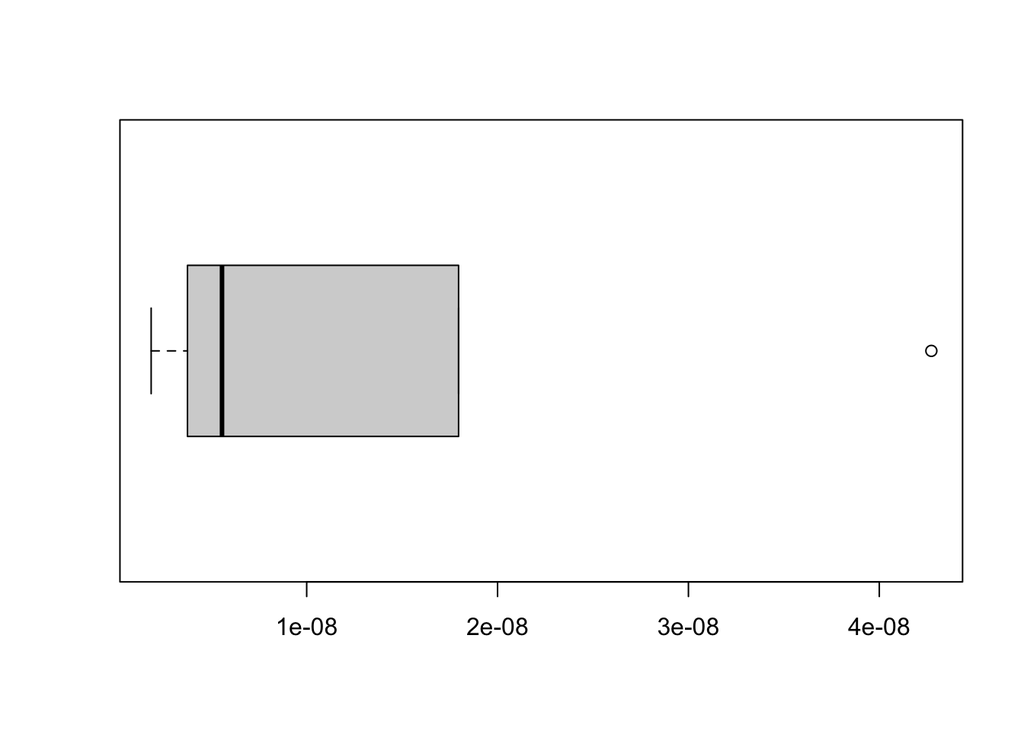

```r
boxplot(MSE_mix, horizontal = TRUE)
```

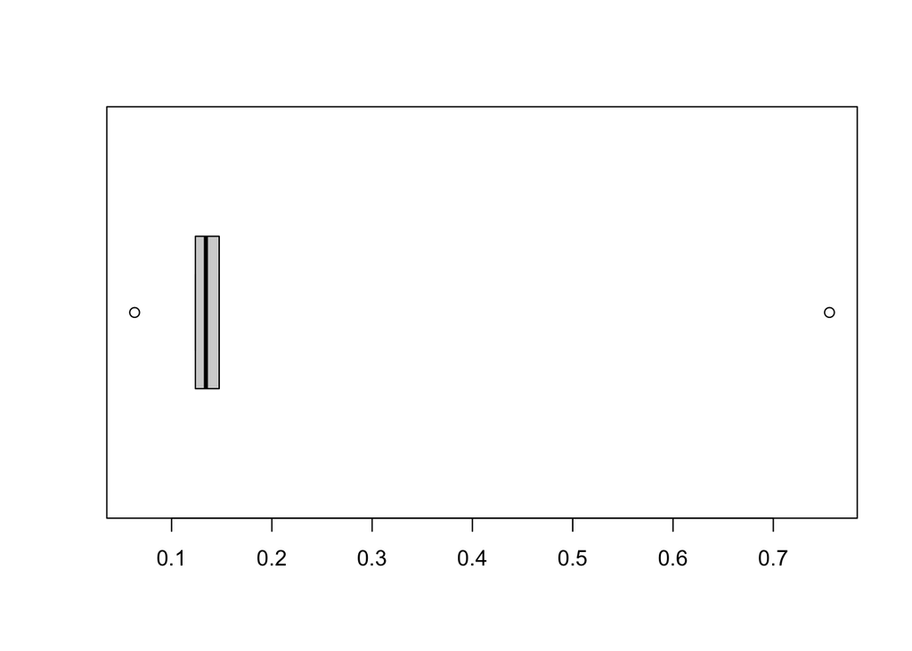

```r
boxplot(QLIKE_mix, horizontal = TRUE)
```

### compare with lm

```r
MSE_lm <- vector()
QLIKE_lm <- vector()
for (i in 1 : length(vol.val)) {
  MSE_lm <- c(MSE_lm,mean( vol.val[[i]]$volatility - pred2[[i]]$fitted) ^ 2)
  QLIKE_lm <- c(QLIKE_lm, mean(vol.val[[i]]$volatility/ pred2[[i]]$fitted -
                                 log(vol.val[[i]]$volatility/ pred2[[i]]$fitted) - 1))
}
```

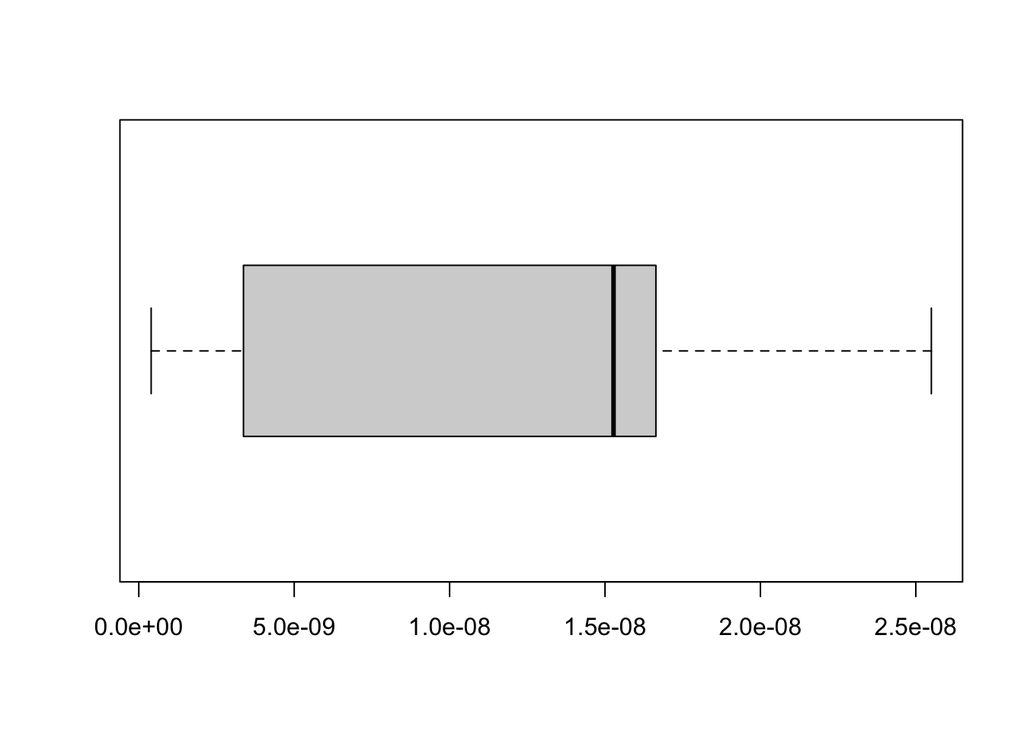

```r
boxplot(MSE_lm, horizontal = TRUE)
```

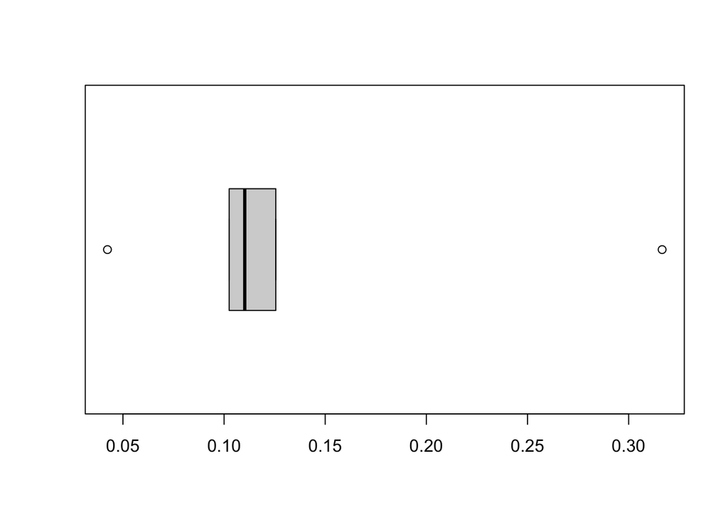

```r
boxplot(QLIKE_lm, horizontal = TRUE)
```

### mean compare

```r
mean(MSE_mix)
```

```
[1] 1.437082e-08
```

```r
mean(MSE_lm)
```

```
[1] 1.223527e-08
```

```r
mean(QLIKE_mix)
```

```
[1] 0.2449328
```

```r
mean(QLIKE_lm)
```

```
[1] 0.1394474
```

## period 1

result = last 120 second

each time = 30 second (17 = 1-30,…,20 = 91-120)

### table

```r
time_pres <- c(17:20)
df1 = data.frame(time_pres,result_pred[[1]]$pred,vol.val[[1]]$volatility
                ,pred1_adjust[[1]]$fitted,pred2[[1]]$fitted)
colnames(df1) <- c('time_period','mix_result','test_vol','egarch','lm')
df1
```

| time_period | mix_result | test_vol | egarch | lm |
| --- | --- | --- | --- | --- |
| 17 | 0.0008760253 | 0.0015946080 | 0.0002022617 | 0.0008760253 |
| 18 | 0.0010611282 | 0.0007010344 | 0.0002053372 | 0.0010611282 |
| 19 | 0.0005999777 | 0.0007203055 | 0.0002042623 | 0.0008637879 |
| 20 | 0.0004784357 | 0.0008264389 | 0.0002038100 | 0.0005470921 |

### visual

red = real test volume

blue = mix model result

orange = model 1

black = model 2

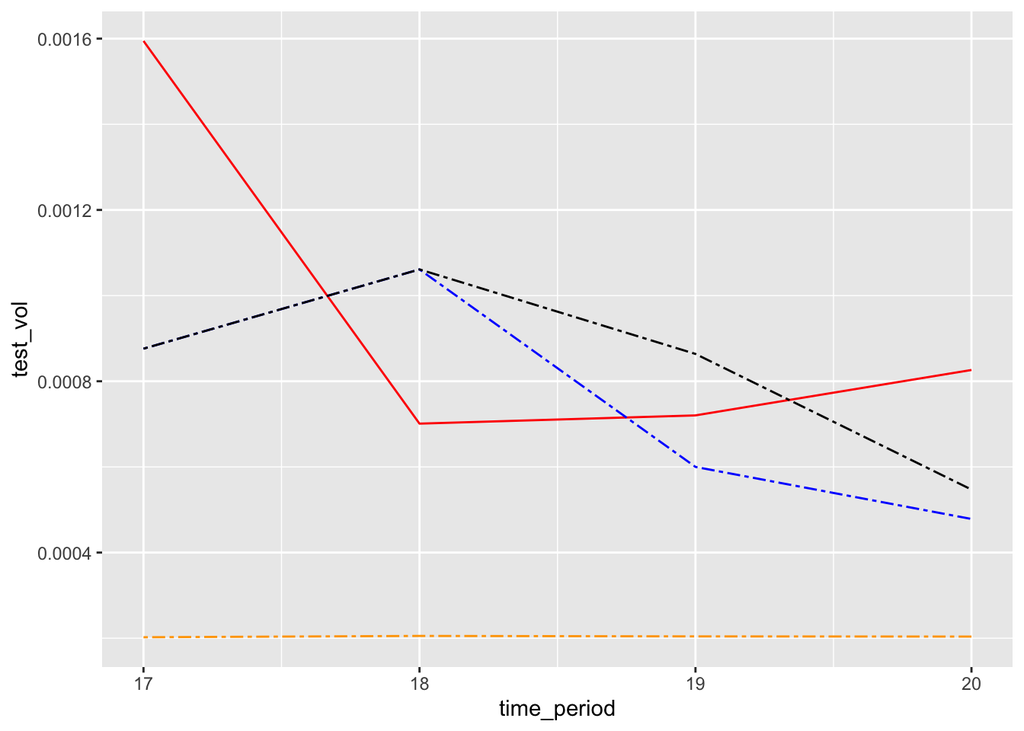

```r
ggplot(df1, aes(x=time_period)) +
  geom_line(aes(y = test_vol),color = "red")+
  geom_line(aes(y = mix_result),color = "blue", linetype="twodash")+
  geom_line(aes(y = egarch),color = "orange", linetype="twodash")+
  geom_line(aes(y = lm),color = "black", linetype="twodash")
```

## period 2

### table

```r
df2 = data.frame(time_pres,result_pred[[2]]$pred,vol.val[[2]]$volatility
                ,pred1_adjust[[2]]$fitted,pred2[[2]]$fitted)
colnames(df2) <- c('time_period','mix_result','test_vol','egarch','lm')
df2
```

| time_period | mix_result | test_vol | egarch | lm |
| --- | --- | --- | --- | --- |
| 17 | 0.0004997687 | 0.0006225340 | 0.0001235121 | 0.0005106239 |
| 18 | 0.0003819583 | 0.0003323998 | 0.0001232570 | 0.0003819583 |
| 19 | 0.0004366059 | 0.0001328152 | 0.0001238678 | 0.0005147904 |
| 20 | 0.0001233923 | 0.0001088957 | 0.0001233923 | 0.0004280157 |

### visual

red = real test volume

blue = mix model result

orange = model 1

black = model 2

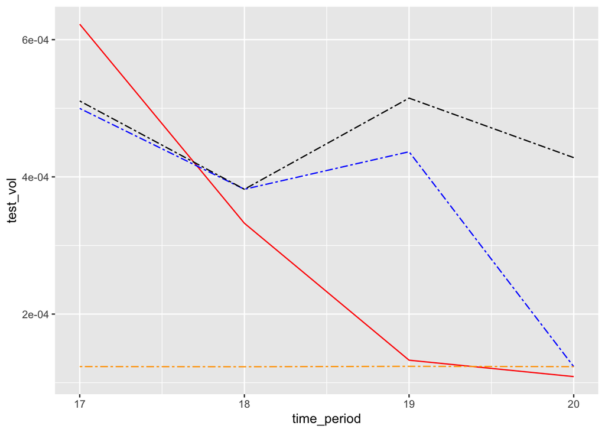

```r
ggplot(df2, aes(x=time_period)) +
  geom_line(aes(y = test_vol),color = "red")+
  geom_line(aes(y = mix_result),color = "blue", linetype="twodash")+
  geom_line(aes(y = egarch),color = "orange", linetype="twodash")+
  geom_line(aes(y = lm),color = "black", linetype="twodash")
```

## period 3

### table

```r
df3 = data.frame(time_pres,result_pred[[3]]$pred,vol.val[[3]]$volatility
                ,pred1_adjust[[3]]$fitted,pred2[[3]]$fitted)
colnames(df3) <- c('time_period','mix_result','test_vol','egarch','lm')
df3
```

| time_period | mix_result | test_vol | egarch | lm |
| --- | --- | --- | --- | --- |
| 17 | 0.0008760253 | 0.0011320570 | 0.0001587247 | 0.0008685312 |
| 18 | 0.0008178390 | 0.0010788897 | 0.0001602532 | 0.0008178390 |
| 19 | 0.0012485565 | 0.0007937135 | 0.0001585966 | 0.0012485565 |
| 20 | 0.0004983845 | 0.0007345000 | 0.0001592514 | 0.0007244733 |

### visual

red = real test volume

blue = mix model result

orange = model 1

black = model 2

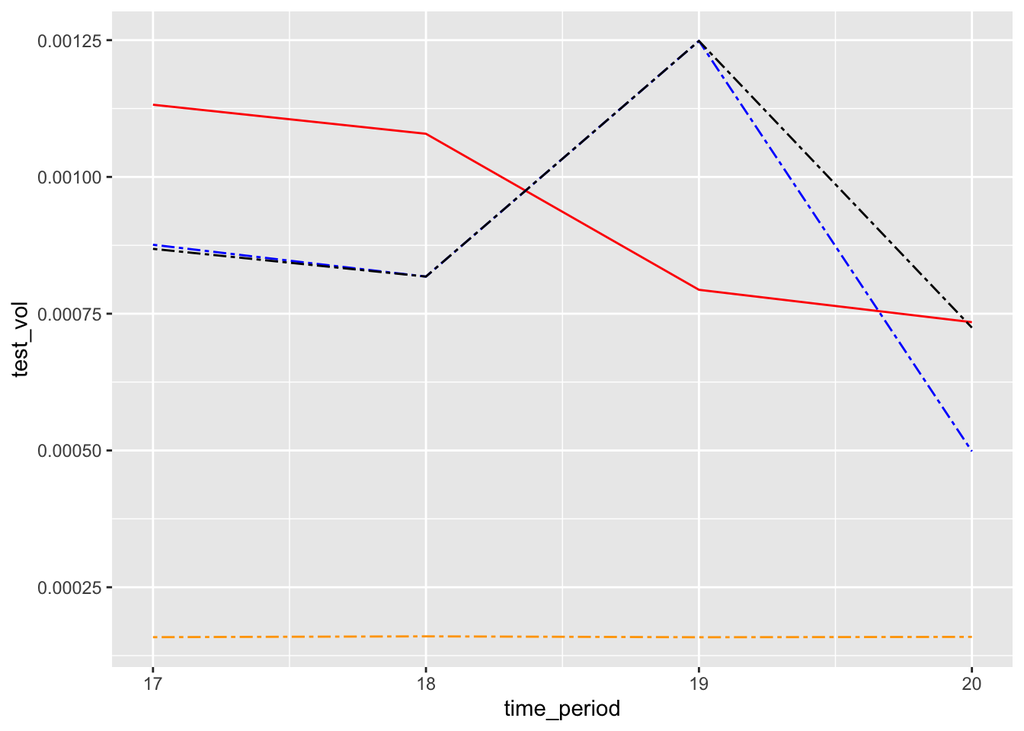

```r
ggplot(df3, aes(x=time_period)) +
  geom_line(aes(y = test_vol),color = "red")+
  geom_line(aes(y = mix_result),color = "blue", linetype="twodash")+
  geom_line(aes(y = egarch),color = "orange", linetype="twodash")+
  geom_line(aes(y = lm),color = "black", linetype="twodash")
```

## period 4

### table

```r
df4 = data.frame(time_pres,result_pred[[4]]$pred,vol.val[[4]]$volatility
                ,pred1_adjust[[4]]$fitted,pred2[[4]]$fitted)
colnames(df4) <- c('time_period','mix_result','test_vol','egarch','lm')
df4
```

| time_period | mix_result | test_vol | egarch | lm |
| --- | --- | --- | --- | --- |
| 17 | 0.0008760253 | 0.0004778847 | 4.044447e-05 | 0.0006338257 |
| 18 | 0.0004093306 | 0.0005119734 | 4.065371e-05 | 0.0005673349 |
| 19 | 0.0006178238 | 0.0007271090 | 4.078582e-05 | 0.0006819391 |
| 20 | 0.0005392948 | 0.0001894792 | 4.021235e-05 | 0.0005392948 |

### visual

red = real test volume

blue = mix model result

orange = model 1

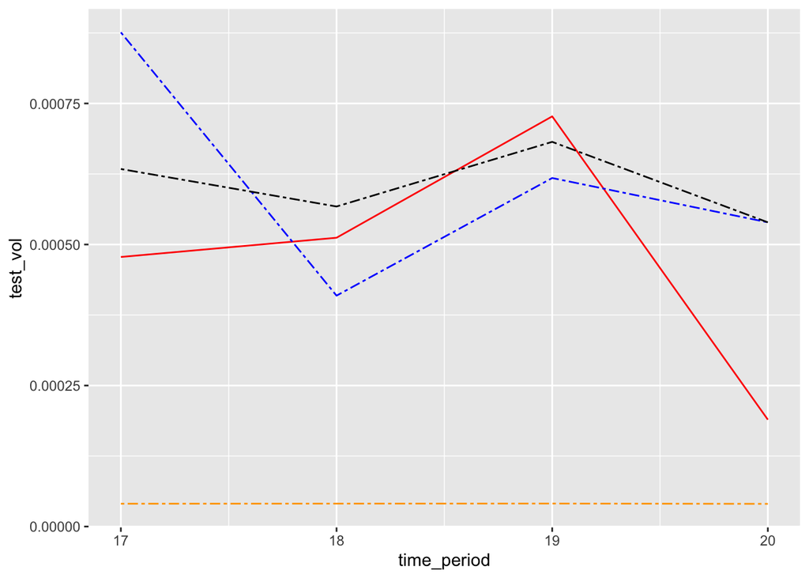

```r
ggplot(df4, aes(x=time_period)) +
  geom_line(aes(y = test_vol),color = "red")+
  geom_line(aes(y = mix_result),color = "blue", linetype="twodash")+
  geom_line(aes(y = egarch),color = "orange", linetype="twodash")+
  geom_line(aes(y = lm),color = "black", linetype="twodash")
```

### table

```r
df5 = data.frame(time_pres,result_pred[[5]]$pred,vol.val[[5]]$volatility
                ,pred1_adjust[[5]]$fitted,pred2[[5]]$fitted)
colnames(df5) <- c('time_period','mix_result','test_vol','egarch','lm')
df5
```

| time_period | mix_result | test_vol | egarch | lm |
| --- | --- | --- | --- | --- |
| 17 | 0.0008760253 | 0.0001584394 | 0.0001243580 | 0.0004225348 |
| 18 | 0.0001687351 | 0.0007691548 | 0.0001250126 | 0.0005622372 |
| 19 | 0.0006444264 | 0.0006672344 | 0.0001230050 | 0.0006444264 |
| 20 | 0.0005440413 | 0.0008105287 | 0.0001244452 | 0.0005440413 |

### visual

red = real test volume

blue = mix model result

orange = model 1

black = model 2

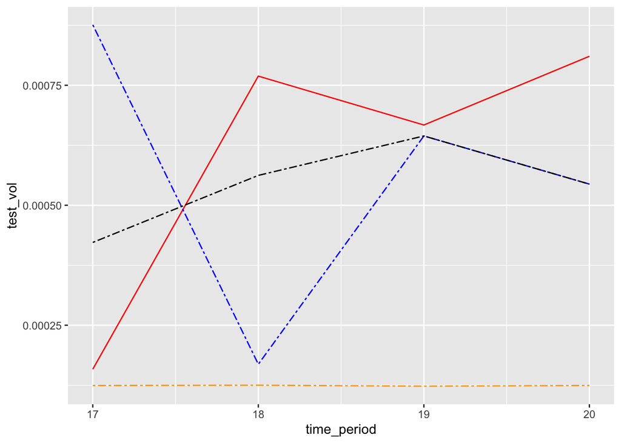

```r
ggplot(df5, aes(x=time_period)) +
  geom_line(aes(y = test_vol),color = "red")+
  geom_line(aes(y = mix_result),color = "blue", linetype="twodash")+
  geom_line(aes(y = egarch),color = "orange", linetype="twodash")+
  geom_line(aes(y = lm),color = "black", linetype="twodash")
```